# Trauma-Associated Page Kidney: A Systematic Review and Data Analysis

# Patient Demographics and Baseline Characteristics

## Age Distribution Analysis

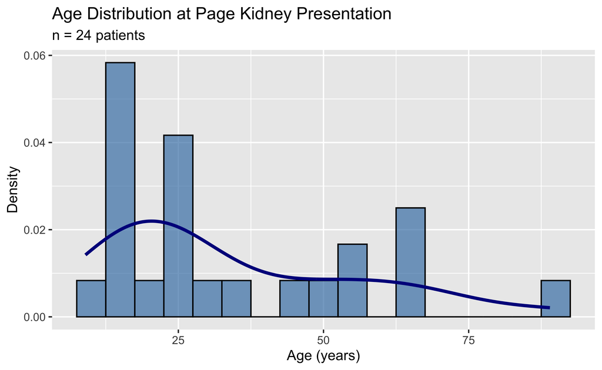

```r
# Comprehensive age statistics using your original approach
describe_age <- function(x) {
  sprintf(
    "The median age at presentation was %.0f years (IQR: %.0f–%.0f, range: %.0f–%.0f). The mean age was %.1f ± %.1f years.",
    median(x, na.rm = TRUE),
    quantile(x, 0.25, na.rm = TRUE),
    quantile(x, 0.75, na.rm = TRUE),
    min(x, na.rm = TRUE),
    max(x, na.rm = TRUE),
    mean(x, na.rm = TRUE),
    sd(x, na.rm = TRUE)
  )
}

age_description <- describe_age(df$age)

# Create publication-quality age distribution plot
ggplot(df, aes(x = age)) +
  geom_histogram(aes(y = after_stat(density)), binwidth = 5,
                 fill = "steelblue", color = "black", alpha = 0.7) +
  geom_density(color = "darkblue", linewidth = 1.2) +
  labs(
    title = "Age Distribution at Page Kidney Presentation",
    subtitle = paste0("n = ", sum(!is.na(df$age)), " patients"),
    x = "Age (years)",
    y = "Density"
  )
```

```r
# Summary statistics table
age_stats <- data.frame(
  Statistic = c("n", "Median (IQR)", "Mean ± SD", "Range"),
  Value = c(
    sum(!is.na(df$age)),
    paste0(median(df$age, na.rm = TRUE), " (",
           quantile(df$age, 0.25, na.rm = TRUE), "–",
           quantile(df$age, 0.75, na.rm = TRUE), ")"),
    paste0(round(mean(df$age, na.rm = TRUE), 1), " ± ",
           round(sd(df$age, na.rm = TRUE), 1)),
    paste0(min(df$age, na.rm = TRUE), "–", max(df$age, na.rm = TRUE))
  )
)

age_stats %>%
  kbl(caption = "Age Distribution Summary",
      align = "lc") %>%
  kable_styling(bootstrap_options = c("striped", "hover"),
                full_width = FALSE)
```

Age Distribution Summary

| Statistic | Value |
| --- | --- |
| n | 24 |
| Median (IQR) | 24.5 (16.75–49.5) |
| Mean ± SD | 34.2 ± 21.7 |
| Range | 9–89 |

**Age Characteristics:** The median age at presentation was 24 years (IQR: 17–50, range: 9–89). The mean age was 34.2 ± 21.7 years.

## Gender Distribution

```r
# Gender analysis maintaining your original approach
gender_counts <- table(df$gender)
total_patients <- nrow(df)
```

**Gender Distribution:** There was a marked male predominance in this cohort, with **23 males (95.8%)** and **1 females (4.2%)**. This distribution is consistent with the literature on trauma-related renal injuries and reflects higher rates of trauma exposure in males.

# Clinical Characteristics

## Past Medical History Analysis

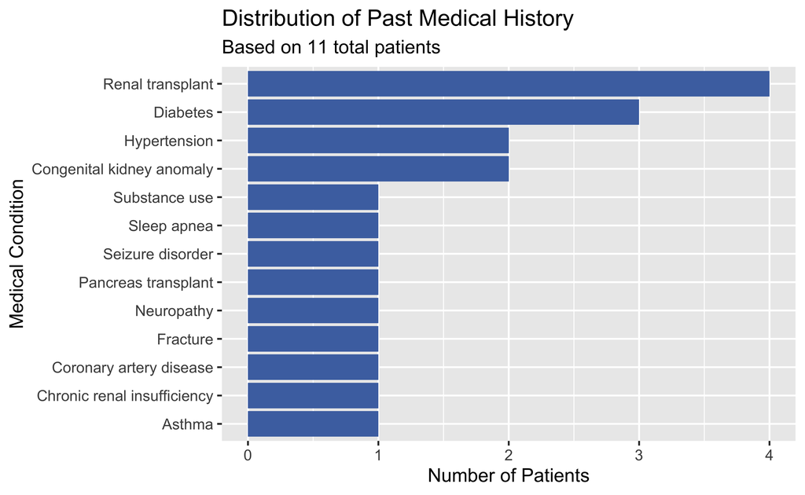

```r
# Your original PMH processing approach with enhanced formatting
pmh_vec <- df$pmh

pmh_clean <- data.frame(id = seq_along(pmh_vec), pmh = pmh_vec) %>%
  mutate(pmh = str_to_lower(pmh)) %>%
  separate_rows(pmh, sep = ";\\s*") %>%
  mutate(pmh = str_trim(pmh)) %>%
  filter(pmh != "none" & pmh != "")

# Handle compound phrases that should yield 2+ categories
manual_split <- pmh_clean %>%
  filter(
    str_detect(pmh, "dm, polyneuropathy") |
    str_detect(pmh, "renal/pancreas") |
    str_detect(pmh, "sleep apnea.*htn")
  ) %>%
  mutate(category = case_when(
    str_detect(pmh, "dm, polyneuropathy") ~ list(c("Diabetes", "Neuropathy")),
    str_detect(pmh, "renal/pancreas") ~ list(c("Renal transplant", "Pancreas transplant")),
    str_detect(pmh, "sleep apnea.*htn") ~ list(c("Sleep apnea", "Hypertension"))
  )) %>%
  unnest_longer(category)

pmh_main <- pmh_clean %>%
  filter(!pmh %in% manual_split$pmh)

# categorization logic
pmh_main <- pmh_main %>%
  mutate(category = case_when(
    str_detect(pmh, "pancreas transplant|renal/pancreas|pancreas") ~ "Pancreas transplant",
    str_detect(pmh, "renal txp|renal transplant") ~ "Renal transplant",
    str_detect(pmh, "htn|hypertension|hctz|losartan|amlodipine") ~ "Hypertension",
    str_detect(pmh, "dm|diabetes") ~ "Diabetes",
    str_detect(pmh, "cad") ~ "Coronary artery disease",
    str_detect(pmh, "chronic renal|renal insufficiency|crf") ~ "Chronic renal insufficiency",
    str_detect(pmh, "glomerulonephritis") ~ "Glomerulonephritis",
    str_detect(pmh, "absent|congenital|atrophic") ~ "Congenital kidney anomaly",
    str_detect(pmh, "seizure") ~ "Seizure disorder",
    str_detect(pmh, "asthma") ~ "Asthma",
    str_detect(pmh, "sleep apnea|cpap") ~ "Sleep apnea",
    str_detect(pmh, "polyneuropathy|neuropathy") ~ "Neuropathy",
    str_detect(pmh, "fracture") ~ "Fracture",
    str_detect(pmh, "marijuana") ~ "Substance use",
    TRUE ~ "Other"
  ))

pmh_all <- bind_rows(pmh_main, manual_split)

# Get total number of patients
total_patients <- n_distinct(df$pmh)

# Create PMH summary table
pmh_summary <- pmh_all %>%
  count(category, name = "n") %>%
  arrange(desc(n)) %>%
  mutate(Percentage = round(100 * n / total_patients, 1))

# Professional visualization
ggplot(pmh_summary, aes(x = reorder(category, n), y = n)) +
  geom_col(fill = "#4C72B0") +
  coord_flip() +
  labs(
    title = "Distribution of Past Medical History",
    subtitle = paste0("Based on ", total_patients, " total patients"),
    x = "Medical Condition",
    y = "Number of Patients"
  )
```

```r
# Summary table
pmh_summary %>%
  select(`Medical Condition` = category, n, `Percentage (%)` = Percentage) %>%
  kbl(caption = "Past Medical History Distribution",
      align = "lcc") %>%
  kable_styling(bootstrap_options = c("striped", "condensed"),
                full_width = FALSE)
```

Past Medical History Distribution

| Medical Condition | n | Percentage (%) |
| --- | --- | --- |
| Renal transplant | 4 | 36.4 |
| Diabetes | 3 | 27.3 |
| Congenital kidney anomaly | 2 | 18.2 |
| Hypertension | 2 | 18.2 |
| Asthma | 1 | 9.1 |
| Chronic renal insufficiency | 1 | 9.1 |
| Coronary artery disease | 1 | 9.1 |
| Fracture | 1 | 9.1 |
| Neuropathy | 1 | 9.1 |
| Pancreas transplant | 1 | 9.1 |
| Seizure disorder | 1 | 9.1 |
| Sleep apnea | 1 | 9.1 |
| Substance use | 1 | 9.1 |

**Past Medical History Summary:**

The most common comorbidities included **hypertension** (n = 2), **diabetes** (n = 3), and **renal transplant** (n = 4). Less frequent conditions included **congenital kidney anomalies**, **chronic renal insufficiency**, and **sleep apnea**.

Several patients had multiple comorbidities. Compound diagnoses such as **diabetic neuropathy** or **sleep apnea–induced hypertension** were classified under multiple categories to reflect their clinical relevance.

## Time from Injury to Diagnosis

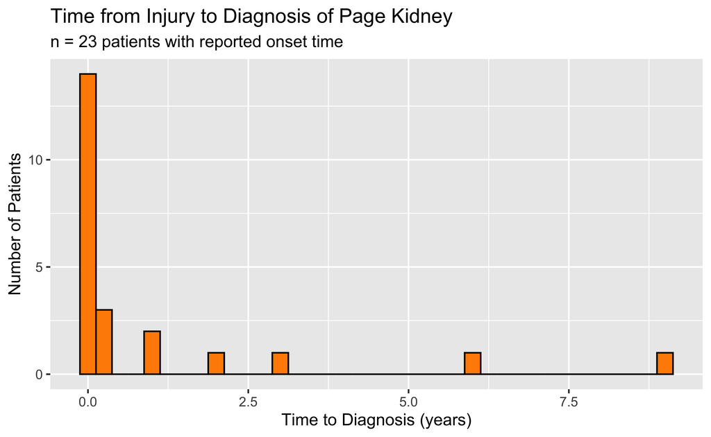

```r
# onset analysis
onset_stats <- list(
  summary = summary(df$onset.y),
  mean = mean(df$onset.y, na.rm = TRUE),
  sd = sd(df$onset.y, na.rm = TRUE),
  quantiles = quantile(df$onset.y, probs = c(0.25, 0.5, 0.75), na.rm = TRUE)
)

# histogram
ggplot(df, aes(x = onset.y)) +
  geom_histogram(binwidth = 0.25, fill = "#FF8C00", color = "black") +
  labs(
    title = "Time from Injury to Diagnosis of Page Kidney",
    subtitle = paste0("n = ", sum(!is.na(df$onset.y)), " patients with reported onset time"),
    x = "Time to Diagnosis (years)",
    y = "Number of Patients"
  )
```

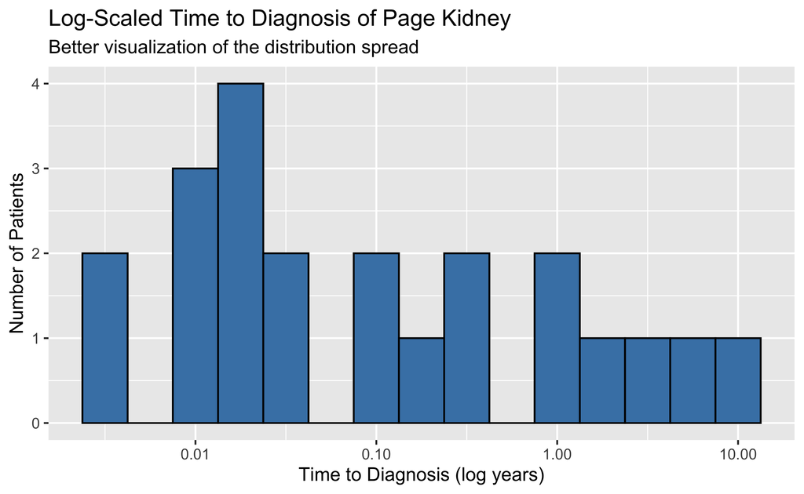

```r
# log-scaled plot
ggplot(df, aes(x = onset.y)) +
  geom_histogram(binwidth = 0.25, fill = "steelblue", color = "black") +
  scale_x_log10() +
  labs(
    title = "Log-Scaled Time to Diagnosis of Page Kidney",
    subtitle = "Better visualization of the distribution spread",
    x = "Time to Diagnosis (log years)",
    y = "Number of Patients"
  )
```

```r
# Summary statistics table
onset_summary_table <- data.frame(
  Statistic = c("n", "Median", "IQR", "Mean ± SD", "Range"),
  `Time (years)` = c(
    sum(!is.na(df$onset.y)),
    round(median(df$onset.y, na.rm = TRUE), 2),
    paste0(round(quantile(df$onset.y, 0.25, na.rm = TRUE), 2), "–",
           round(quantile(df$onset.y, 0.75, na.rm = TRUE), 2)),
    paste0(round(mean(df$onset.y, na.rm = TRUE), 2), " ± ",
           round(sd(df$onset.y, na.rm = TRUE), 2)),
    paste0(round(min(df$onset.y, na.rm = TRUE), 3), "–",
           round(max(df$onset.y, na.rm = TRUE), 1))
  ),
  `Time (days)` = c(
    "",
    round(median(df$onset.y, na.rm = TRUE) * 365),
    paste0(round(quantile(df$onset.y, 0.25, na.rm = TRUE) * 365), "–",
           round(quantile(df$onset.y, 0.75, na.rm = TRUE) * 365)),
    paste0(round(mean(df$onset.y, na.rm = TRUE) * 365), " ± ",
           round(sd(df$onset.y, na.rm = TRUE) * 365)),
    paste0(round(min(df$onset.y, na.rm = TRUE) * 365), "–",
           round(max(df$onset.y, na.rm = TRUE) * 365))
  )
)

onset_summary_table %>%
  kbl(caption = "Time from Injury to Page Kidney Diagnosis",
      align = "lcc") %>%
  kable_styling(bootstrap_options = c("striped", "hover"),
                full_width = FALSE)
```

Time from Injury to Page Kidney Diagnosis

| Statistic | Time..years. | Time..days. |
| --- | --- | --- |
| n | 23 |  |
| Median | 0.04 | 15 |
| IQR | 0.01–0.67 | 5–243 |
| Mean ± SD | 1 ± 2.23 | 367 ± 813 |
| Range | 0–9 | 0–3285 |

**Time from Injury to Diagnosis:**

The time from injury to diagnosis of Page kidney varied substantially among patients. The **median time to diagnosis** was approximately **0.04 years** (~15 days), with an **interquartile range (IQR)** of **0.01 to 0.67 years**.

The **mean** time to diagnosis was **1 ± 2.23 years**, and the **range** extended from **0 to 9 years**.

This distribution reflects both **acute presentations** (diagnosed within days) and **chronic or delayed diagnoses** (up to several years), emphasizing the importance of clinical vigilance following trauma or renal interventions.

## Mechanism of Injury

```r
# mechanism analysis
total_patients <- nrow(df)
mechanism_summary <- as.data.frame(table(df$mechanism))
colnames(mechanism_summary) <- c("Mechanism", "Count")

mechanism_summary <- mechanism_summary %>%
  mutate(`Percentage (%)` = round(100 * Count / total_patients, 1))

mechanism_summary %>%
  kbl(caption = "Mechanism of Injury Leading to Page Kidney",
      align = "lcc") %>%
  kable_styling(bootstrap_options = c("striped", "hover"),
                full_width = FALSE)
```

Mechanism of Injury Leading to Page Kidney

| Mechanism | Count | Percentage (%) |
| --- | --- | --- |
| blunt | 12 | 50 |
| fall | 6 | 25 |
| mvc | 6 | 25 |

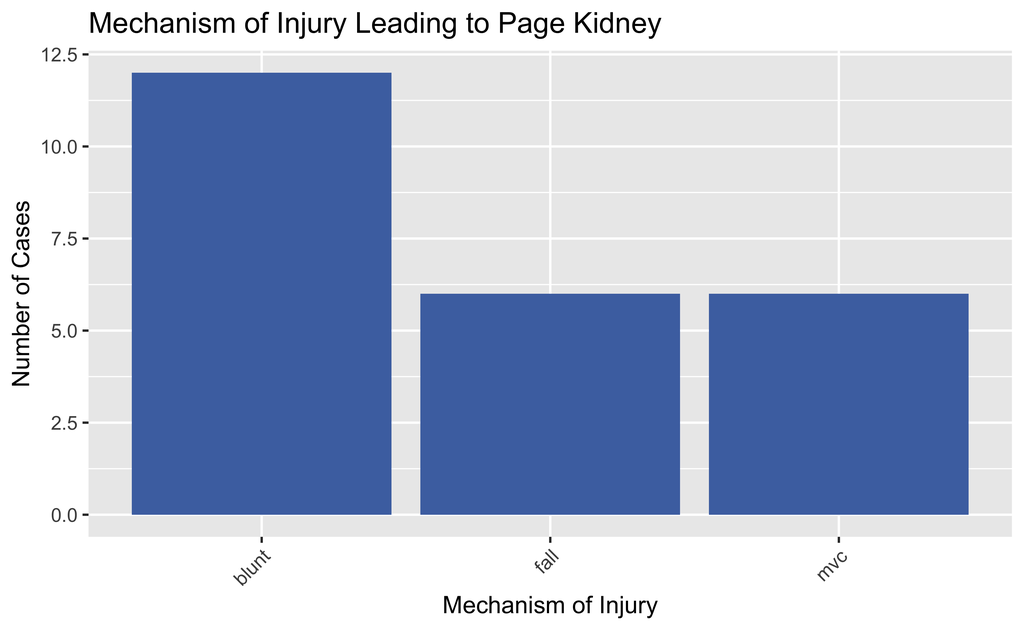

```r
# Professional bar plot
ggplot(mechanism_summary, aes(x = reorder(Mechanism, -Count), y = Count)) +
  geom_col(fill = "#4C72B0") +
  labs(
    title = "Mechanism of Injury Leading to Page Kidney",
    x = "Mechanism of Injury",
    y = "Number of Cases"
  ) +
  theme(axis.text.x = element_text(angle = 45, hjust = 1))
```

**Mechanism of Injury:**

Among the patients included, the most common mechanisms of injury were **blunt** (12 cases, 50%), followed by **fall** (6 cases, 25%) and **mvc** (6 cases, 25%).

## Clinical Presentation and Symptoms

```r
# symptom processing
df <- df %>%
  mutate(
    ss_combined = ifelse(hypertension,
                         ifelse(ss == "" | is.na(ss), "hypertension", paste(ss, "hypertension", sep = "; ")),
                         ss)
  )

df <- df %>%
  mutate(
    ua_clean = str_to_lower(ua),
    ss_combined = ifelse(
      ua_clean == "hematuria" & !str_detect(str_to_lower(ss_combined), "hematuria"),
      ifelse(is.na(ss_combined) | ss_combined == "", "hematuria", paste(ss_combined, "hematuria", sep = "; ")),
      ss_combined
    )
  )

# Create ID and clean the combined symptom column
ss_clean <- data.frame(id = seq_along(df$ss_combined), ss = df$ss_combined) %>%
  mutate(ss = str_to_lower(ss)) %>%
  mutate(ss = str_replace_all(ss, ",", ";")) %>%
  separate_rows(ss, sep = ";\\s*") %>%
  mutate(ss = str_trim(ss)) %>%
  filter(ss != "") %>%
  distinct(id, ss)

# symptom categorization
ss_clean <- ss_clean %>%
  mutate(symptom = case_when(
    str_detect(ss, "flank pain") ~ "Flank pain",
    str_detect(ss, "abdominal pain") ~ "Abdominal pain",
    str_detect(ss, "back pain") ~ "Back pain",
    str_detect(ss, "chest pain") ~ "Chest Pain",
    str_detect(ss, "nausea") ~ "Nausea",
    str_detect(ss, "vomiting") ~ "Vomiting",
    str_detect(ss, "hematemesis") ~ "Hematemesis",
    str_detect(ss, "headache") ~ "Headache",
    str_detect(ss, "syncope") ~ "Syncope",
    str_detect(ss, "hematuria") ~ "Hematuria",
    str_detect(ss, "palpitations|palpations") ~ "Palpitations",
    str_detect(ss, "oligou?ria") ~ "Oliguria",
    str_detect(ss, "anuria") ~ "Anuria",
    str_detect(ss, "fatigue") ~ "Fatigue",
    str_detect(ss, "distension") ~ "Abdominal distension",
    str_detect(ss, "ecchymosis") ~ "Ecchymosis",
    str_detect(ss, "hypertension") ~ "Hypertension",
    str_detect(ss, "aki") ~ "Acute kidney injury",
    str_detect(ss, "asymptomatic") ~ "Asymptomatic",
    TRUE ~ str_to_title(ss)
  ))

symptom_summary <- ss_clean %>%
  count(symptom, sort = TRUE) %>%
  mutate(Percentage = round(100 * n / n_distinct(ss_clean$id), 1))

symptom_summary %>%
  kbl(caption = "Presenting Symptoms and Signs",
      col.names = c("Symptom", "Count", "Percentage (%)"),
      align = "lcc") %>%
  kable_styling(bootstrap_options = c("striped", "hover", "condensed"),
                full_width = FALSE)
```

Presenting Symptoms and Signs

| Symptom | Count | Percentage (%) |
| --- | --- | --- |
| Hypertension | 13 | 92.9 |
| Flank pain | 8 | 57.1 |
| Hematuria | 7 | 50.0 |
| Abdominal pain | 4 | 28.6 |
| Back pain | 2 | 14.3 |
| Headache | 2 | 14.3 |
| Abdominal distension | 1 | 7.1 |
| Asymptomatic | 1 | 7.1 |
| Chest Pain | 1 | 7.1 |
| Ecchymosis | 1 | 7.1 |
| Fatigue | 1 | 7.1 |
| Palpitations | 1 | 7.1 |
| Vomiting | 1 | 7.1 |

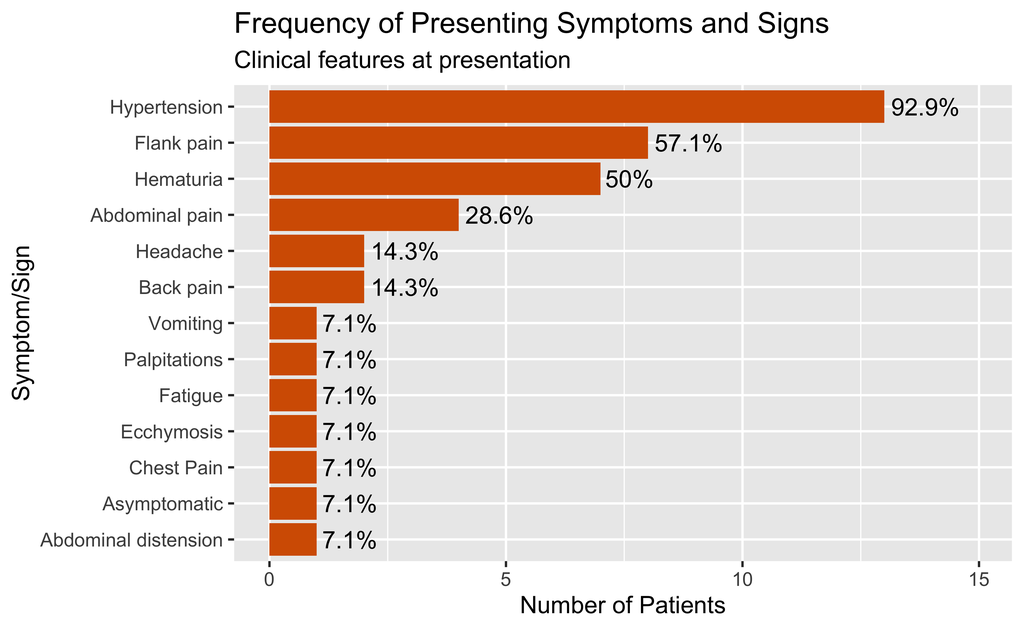

```r
# Professional symptom plot
ggplot(symptom_summary, aes(x = reorder(symptom, n), y = n)) +
  geom_col(fill = "#D55E00") +
  geom_text(aes(label = paste0(Percentage, "%")), hjust = -0.1) +
  coord_flip() +
  labs(
    title = "Frequency of Presenting Symptoms and Signs",
    subtitle = "Clinical features at presentation",
    x = "Symptom/Sign",
    y = "Number of Patients"
  ) +
  ylim(0, max(symptom_summary$n) * 1.15)
```

**Clinical Presentation:**

Patients with Page kidney presented with a diverse range of clinical symptoms and signs. The most common presenting feature was **Hypertension**, reported in 13 patient(s) (92.9%). This was followed by **Flank pain** (8 patients, 57.1%) and **Hematuria** (7 patients, 50%).

# Diagnostic Findings

## Urinalysis Results

```r
ua_summary <- df %>%
  mutate(ua_result = case_when(
    is.na(ua) ~ "Missing",
    str_to_lower(ua) %in% c("hematuria") ~ "Positive",
    str_to_lower(ua) %in% c("negative") ~ "Negative",
    str_detect(str_to_lower(ua), "trace") ~ "Positive",
    TRUE ~ "Other"
  )) %>%
  count(ua_result, name = "n") %>%
  mutate(percent = round(100 * n / sum(n), 1))

ua_summary %>%
  kbl(caption = "Urinalysis Results Distribution",
      col.names = c("Urinalysis Result", "n", "Percentage (%)"),
      align = "lcc") %>%
  kable_styling(bootstrap_options = c("striped", "hover", "condensed"),
                full_width = FALSE)
```

Urinalysis Results Distribution

[output not shown]

## Injury Grade Assessment

```r
grade_summary <- df %>%
  count(grade, name = "n", drop = FALSE) %>%
  mutate(
    Grade = ifelse(is.na(grade), "Missing", as.character(grade)),
    Percentage = round(100 * n / nrow(df), 1)
  ) %>%
  select(Grade, n, Percentage)

grade_summary %>%
  kbl(caption = "Distribution of AAST Kidney Injury Grades",
      align = "lcc") %>%
  kable_styling(bootstrap_options = c("striped", "hover", "condensed"),
                full_width = FALSE)
```

Distribution of AAST Kidney Injury Grades

| Grade | n | Percentage |
| --- | --- | --- |
| II | 1 | 4.2 |
| IV | 1 | 4.2 |
| V | 1 | 4.2 |
| Missing | 21 | 87.5 |

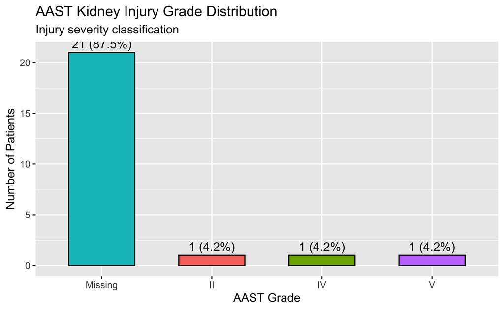

```r
# Professional grade visualization
ggplot(grade_summary, aes(x = reorder(Grade, -n), y = n, fill = Grade)) +
  geom_col(width = 0.6, color = "black") +
  geom_text(aes(label = paste0(n, " (", Percentage, "%)")),
            vjust = -0.5, size = 4) +
  labs(
    title = "AAST Kidney Injury Grade Distribution",
    subtitle = "Injury severity classification",
    x = "AAST Grade",
    y = "Number of Patients"
  ) +
  theme(legend.position = "none")
```

# Page Kidney Imaging Characteristics

## Size of Perinephric Fluid Collections

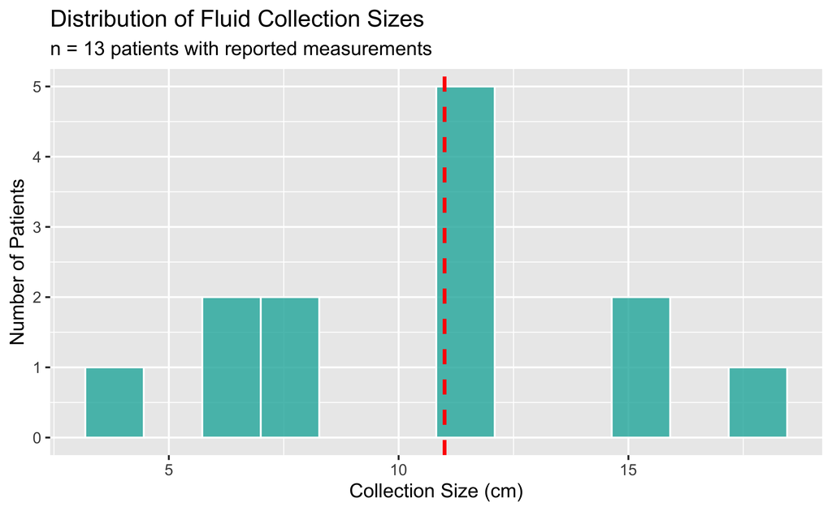

```r
size_summary <- df %>%
  summarise(
    median = median(size.cm, na.rm = TRUE),
    iqr_low = quantile(size.cm, 0.25, na.rm = TRUE),
    iqr_high = quantile(size.cm, 0.75, na.rm = TRUE),
    min = min(size.cm, na.rm = TRUE),
    max = max(size.cm, na.rm = TRUE),
    mean = mean(size.cm, na.rm = TRUE),
    sd = sd(size.cm, na.rm = TRUE),
    missing = sum(is.na(size.cm)),
    total = n()
  )

# Size distribution histogram
ggplot(df %>% filter(!is.na(size.cm)), aes(x = size.cm)) +
  geom_histogram(bins = 12, fill = "#20B2AA", alpha = 0.8, color = "white") +
  geom_vline(aes(xintercept = median(size.cm, na.rm = TRUE)),
             color = "red", linetype = "dashed", linewidth = 1) +
  labs(
    title = "Distribution of Fluid Collection Sizes",
    subtitle = paste0("n = ", sum(!is.na(df$size.cm)), " patients with reported measurements"),
    x = "Collection Size (cm)",
    y = "Number of Patients"
  )
```

```r
# Size summary table
size_stats_table <- data.frame(
  Statistic = c("n", "Median (IQR)", "Mean ± SD", "Range", "Missing"),
  Value = c(
    sum(!is.na(df$size.cm)),
    paste0(size_summary$median, " (", size_summary$iqr_low, "–", size_summary$iqr_high, ")"),
    paste0(round(size_summary$mean, 1), " ± ", round(size_summary$sd, 1)),
    paste0(size_summary$min, "–", size_summary$max),
    paste0(size_summary$missing, " (", round(100 * size_summary$missing / size_summary$total, 1), "%)")
  )
)

size_stats_table %>%
  kbl(caption = "Perinephric Fluid Collection Size Statistics",
      align = "lc") %>%
  kable_styling(bootstrap_options = c("striped", "hover"),
                full_width = FALSE)
```

Perinephric Fluid Collection Size Statistics

| Statistic | Value |
| --- | --- |
| n | 13 |
| Median (IQR) | 11 (7.4–12) |
| Mean ± SD | 10.7 ± 4 |
| Range | 4–18 |
| Missing | 11 (45.8%) |

**Fluid Collection Size Analysis:**

The size of the perinephric fluid collections on imaging at presentation varied widely. The median size was 11 cm (IQR: 7.4–12 cm), with a mean of 10.7 ± 4 cm. The smallest collection measured 4 cm, while the largest was 18 cm. Notably, size data was not reported in 11 out of 24 cases (45.8%).

## Type of Fluid Collection

```r
page_type_summary <- df %>%
  mutate(page_type_clean = ifelse(is.na(page.type), "Missing", as.character(page.type))) %>%
  count(page_type_clean, name = "n") %>%
  mutate(Percentage = round(100 * n / sum(n), 1))

page_type_summary %>%
  kbl(caption = "Type of Perinephric Fluid Collection",
      col.names = c("Collection Type", "n", "Percentage (%)"),
      align = "lcc") %>%
  kable_styling(bootstrap_options = c("striped", "hover"),
                full_width = FALSE)
```

Type of Perinephric Fluid Collection

| Collection Type | n | Percentage (%) |
| --- | --- | --- |
| Missing | 1 | 4.2 |
| hematoma | 21 | 87.5 |
| lymphocele | 1 | 4.2 |
| urinoma | 1 | 4.2 |

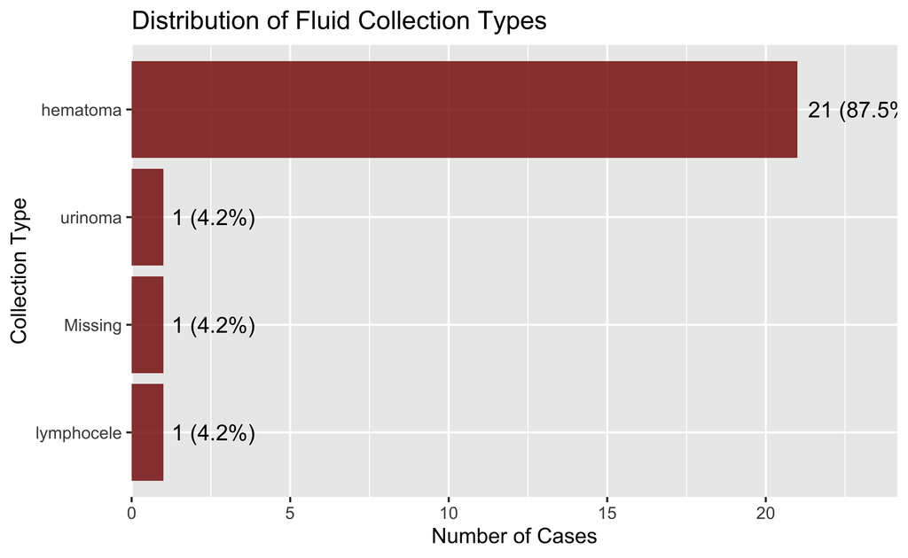

```r
# Visualization
ggplot(page_type_summary, aes(x = reorder(page_type_clean, n), y = n)) +
  geom_col(fill = "#800000", alpha = 0.8) +
  geom_text(aes(label = paste0(n, " (", Percentage, "%)")),
            hjust = -0.1, size = 4) +
  coord_flip() +
  labs(
    title = "Distribution of Fluid Collection Types",
    x = "Collection Type",
    y = "Number of Cases"
  ) +
  scale_y_continuous(expand = expansion(mult = c(0, 0.15)))
```

**Fluid Collection Types:**

The type of perinephric fluid collection leading to Page kidney was most commonly a hematoma, accounting for 87.5% of cases (21 of 24 patients). Other etiologies included:

- **Urinoma**: 1 case(s) (4.2%)
- **Lymphocele**: 1 case(s) (4.2%)
- **Missing Data**: 1 case(s) (4.2%)

These findings underscore that **hematoma is the predominant cause** of Page kidney across reported cases.

## Laterality Distribution

```r
laterality_table <- df %>%
  count(laterality) %>%
  mutate(Percentage = round(100 * n / sum(n), 1))

laterality_table %>%
  kbl(caption = "Distribution of Laterality in Page Kidney Cases",
      align = "lcc") %>%
  kable_styling(bootstrap_options = c("striped", "hover"),
                full_width = FALSE)
```

Distribution of Laterality in Page Kidney Cases

| laterality | n | Percentage |
| --- | --- | --- |
| allograft left | 2 | 8.3 |
| allograft right | 2 | 8.3 |
| bilateral | 2 | 8.3 |
| left | 10 | 41.7 |
| right | 8 | 33.3 |

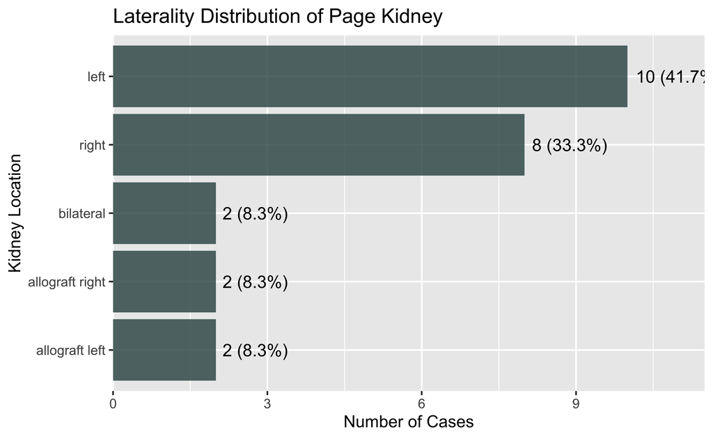

```r
# Laterality visualization
ggplot(laterality_table, aes(x = reorder(laterality, n), y = n)) +
  geom_col(fill = "#2F4F4F", alpha = 0.8) +
  geom_text(aes(label = paste0(n, " (", Percentage, "%)")),
            hjust = -0.1, size = 4) +
  coord_flip() +
  labs(
    title = "Laterality Distribution of Page Kidney",
    x = "Kidney Location",
    y = "Number of Cases"
  ) +
  scale_y_continuous(expand = expansion(mult = c(0, 0.15)))
```

**Laterality Patterns:**

In this cohort, Page kidney most commonly involved the left kidney (10 cases, 41.7%), followed by the right kidney (8 cases, 33.3%). Bilateral involvement was seen in 2 cases. Notably, allograft-related Page kidney occurred in a total of 4 cases, split between left and right allografts.

**Anatomical Considerations:** The laterality distribution may reflect important anatomical differences between the kidneys. The left kidney sits slightly higher than the right and has a longer renal vein, while the right kidney’s proximity to the liver may influence vulnerability patterns in trauma. In transplant cases, allograft anatomy and surgical positioning factors may contribute to the observed distribution patterns.

# Treatment Modalities and Management

```r
treatment_categories <- data.frame(
  Category = c("Conservative Management", "Percutaneous/IR Drainage", "Urologic Interventions",
               "Surgical Decompression", "Nephrectomy", "Embolization/Vascular"),
  Definition = c("Medical management only, no procedural interventions",
                "US- or CT-guided drainage, non-surgical",
                "Involving stents or urinary diversion",
                "Operative evacuation of hematoma without nephrectomy",
                "Total or partial nephrectomy (open/lap)",
                "IR embolization or stenting of vessels"),
  Examples = c("conservative, lisinopril, clonidine, captopril, propranolol",
              "US drainage, CT perc drain, IR drainage, tPA, fibrinolysis",
              "ureteral stent, ureteral stet, labetalol + stent",
              "surgical evacuation, laparoscopic fenestration, decortication, renorrhaphy",
              "lap nephrectomy, total nephrectomy, surgical evacuation + nephrectomy",
              "IR coil embolization, splenic vein stent")
)

treatment_categories %>%
  kbl(caption = "Treatment Category Definitions and Examples") %>%
  kable_styling(bootstrap_options = c("striped", "hover", "condensed"),
                full_width = TRUE) %>%
  column_spec(2, width = "35%") %>%
  column_spec(3, width = "35%")
```

Treatment Category Definitions and Examples

| Category | Definition | Examples |
| --- | --- | --- |
| Conservative Management | Medical management only, no procedural interventions | conservative, lisinopril, clonidine, captopril, propranolol |
| Percutaneous/IR Drainage | US- or CT-guided drainage, non-surgical | US drainage, CT perc drain, IR drainage, tPA, fibrinolysis |
| Urologic Interventions | Involving stents or urinary diversion | ureteral stent, ureteral stet, labetalol + stent |
| Surgical Decompression | Operative evacuation of hematoma without nephrectomy | surgical evacuation, laparoscopic fenestration, decortication, renorrhaphy |
| Nephrectomy | Total or partial nephrectomy (open/lap) | lap nephrectomy, total nephrectomy, surgical evacuation + nephrectomy |
| Embolization/Vascular | IR embolization or stenting of vessels | IR coil embolization, splenic vein stent |

```r
df <- df %>%
  mutate(treatment_lower = tolower(treatment))

df_flags <- df %>%
  mutate(
    Conservative = str_detect(treatment_lower, "conservative|lisinopril|clonidine|captopril|amlodipine|propran|methyldopa|hctz|hydralazine|felodipine|labetolol|nitroprusside") &
                   !str_detect(treatment_lower, "drain|nephrectomy|evacuation|decortication|fenestration|stent|embol|coil|surgery|lap|ureter"),

    Perc_IR = str_detect(treatment_lower, "drain|fibrinolysis|fine needle|tp[a]?") &
              !str_detect(treatment_lower, "surgery|nephrectomy"),

    Urologic = str_detect(treatment_lower, "ureteral stent|stet"),

    Surgical_Decompression = str_detect(treatment_lower, "surgical evacuation|decortication|renorrhaphy|laparotomy|debridement|fenestration") &
               !str_detect(treatment_lower, "nephrectomy"),

    Nephrectomy = str_detect(treatment_lower, "nephrectomy"),

    Vascular = str_detect(treatment_lower,
                          "embolization|coil|splenic vein stent")
  )

# Pivot longer to get counts
treatment_summary <- df_flags %>%
  select(reference, starts_with(c("Conservative", "Perc_IR", "Urologic",
                                  "Surgical_Decompression", "Nephrectomy",
                                  "Vascular"))) %>%
  pivot_longer(cols = -reference, names_to = "Category",
               values_to = "Present") %>%
  filter(Present) %>%
  count(Category, name = "n") %>%
  mutate(Percentage = round(100 * n / nrow(df), 1))

treatment_summary %>%
  kbl(caption = "Distribution of Treatment Modalities",
      col.names = c("Treatment Category", "n", "Percentage (%)"),
      align = "lcc") %>%
  kable_styling(bootstrap_options = c("striped", "hover"),
                full_width = FALSE)
```

Distribution of Treatment Modalities

| Treatment Category | n | Percentage (%) |
| --- | --- | --- |
| Conservative | 3 | 12.5 |
| Nephrectomy | 5 | 20.8 |
| Perc_IR | 6 | 25.0 |
| Surgical_Decompression | 9 | 37.5 |
| Urologic | 2 | 8.3 |
| Vascular | 2 | 8.3 |

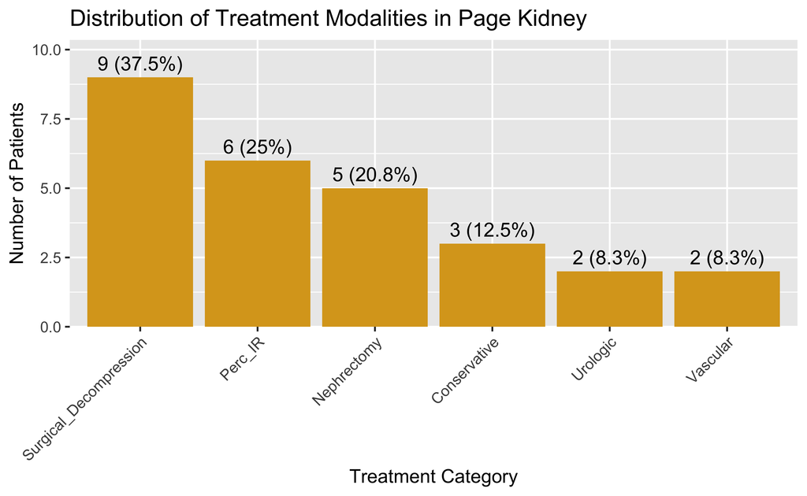

```r
# Treatment distribution plot
ggplot(treatment_summary, aes(x = reorder(Category, -n), y = n)) +
  geom_bar(stat = "identity", fill = "#DAA520") +
  geom_text(aes(label = paste0(n, " (", Percentage, "%)")),
            vjust = -0.5, size = 4) +
  labs(
    title = "Distribution of Treatment Modalities in Page Kidney",
    x = "Treatment Category",
    y = "Number of Patients"
  ) +
  theme(axis.text.x = element_text(angle = 45, hjust = 1)) +
  scale_y_continuous(expand = expansion(mult = c(0, 0.15)))
```

**Treatment Approaches:**

Treatment modalities varied considerably across the cohort. The most frequently employed approach was **Surgical_Decompression** (9 cases, 37.5%), followed by **Perc_IR** (6 cases, 25%).

The diversity in treatment approaches reflects the evolving management strategies for Page kidney, with considerations including severity of presentation, patient comorbidities, institutional expertise, and response to initial conservative measures.

# Clinical Outcomes and Follow-up

```r
df$fu.y <- as.numeric(df$fu.y)

# Summary stats
followup_summary <- df %>%
  summarize(
    `Number with Reported Follow-Up` = sum(!is.na(fu.y)),
    `Mean (years)` = round(mean(fu.y, na.rm = TRUE), 2),
    `Median (years)` = round(median(fu.y, na.rm = TRUE), 2),
    `Min (years)` = round(min(fu.y, na.rm = TRUE), 2),
    `Max (years)` = round(max(fu.y, na.rm = TRUE), 2)
  )

followup_summary %>%
  kbl(caption = "Follow-up Duration Summary",
      align = "lc") %>%
  kable_styling(bootstrap_options = c("striped", "hover"),
                full_width = FALSE)
```

Follow-up Duration Summary

| Number with Reported Follow-Up | Mean (years) | Median (years) | Min (years) | Max (years) |
| --- | --- | --- | --- | --- |
| 20 | 1.1 | 0.38 | 0.01 | 9 |

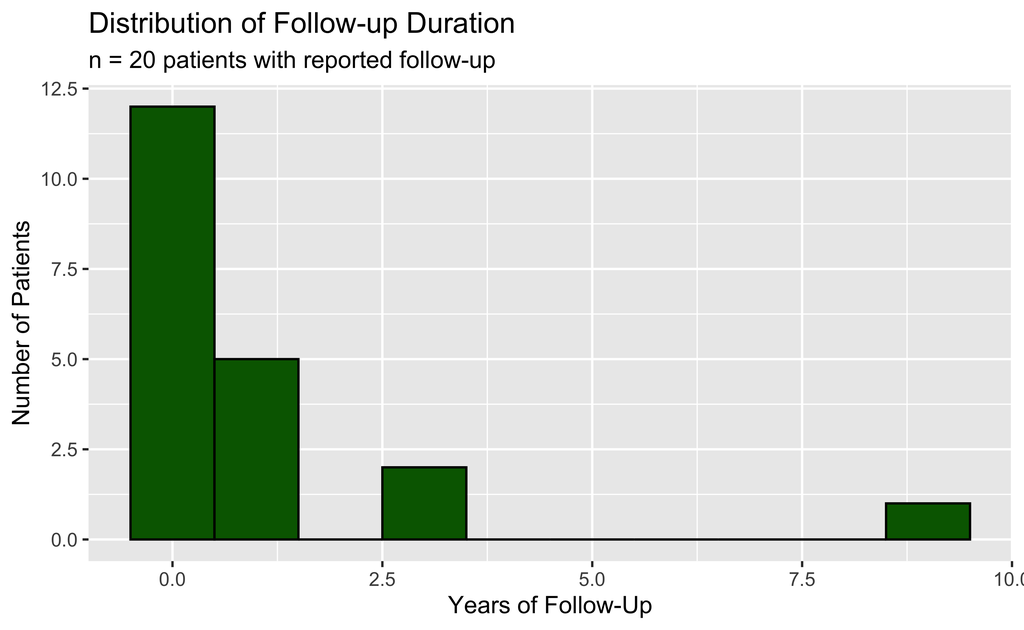

```r
ggplot(df %>% filter(!is.na(fu.y)), aes(x = fu.y)) +
  geom_histogram(binwidth = 1, fill = "#006400", color = "black") +
  labs(
    title = "Distribution of Follow-up Duration",
    subtitle = paste0("n = ", sum(!is.na(df$fu.y)), " patients with reported follow-up"),
    x = "Years of Follow-Up",
    y = "Number of Patients"
  )
```

```r
# Survival/outcome summary
survival_summary <- data.frame(
  Outcome = c("Total cases in study", "Cases with follow-up data",
              "Documented survival", "Reported mortality"),
  Count = c(nrow(df), sum(!is.na(df$fu.y)),
            sum(df$fu.status == TRUE, na.rm = TRUE),
            sum(df$fu.status == FALSE, na.rm = TRUE)),
  Percentage = c(100, round(100 * sum(!is.na(df$fu.y)) / nrow(df), 1),
                round(100 * sum(df$fu.status == TRUE,
                                na.rm = TRUE) / sum(!is.na(df$fu.y)), 1),
                0)
)

survival_summary %>%
  kbl(caption = "Clinical Outcomes Summary",
      align = "lcc") %>%
  kable_styling(bootstrap_options = c("striped", "hover"),
                full_width = FALSE)
```

Clinical Outcomes Summary

[output not shown]

**Follow-up and Clinical Outcomes:**

Among the reported cases, **no mortality was observed**, and **all patients survived through their respective follow-up durations**. Follow-up data were available for 20 out of 24 cases (83.3%).

The average duration of follow-up was **1.1 years** (median: 0.4 years), ranging from **0 to 9 years**.

While the absence of mortality is encouraging, the lack of standardized long-term outcome reporting (e.g., blood pressure control, renal function) limits broader conclusions. Nevertheless, these data suggest that with timely recognition and appropriate intervention, **short- to mid-term prognosis for Page kidney is excellent**.

# Data Export and Workspace Management

```r
pmh_cleaned <- pmh_all %>%
  group_by(id) %>%
  summarise(
    pmh = paste(unique(category), collapse = "; "),
    .groups = "drop"
  )

ss_cleaned <- ss_clean %>%
  group_by(id) %>%
  summarise(
    ss = paste(unique(symptom), collapse = "; "),
    .groups = "drop"
  )

# Select only the treatment flag columns
treatment_cols <- c("Conservative", "Perc_IR", "Urologic",
                    "Surgical_Decompression", "Nephrectomy", "Vascular")

# Create a treatment summary
treatment_cleaned <- df_flags %>%
  mutate(id = row_number()) %>%
  pivot_longer(
    cols = all_of(treatment_cols),
    names_to = "category",
    values_to = "present"
  ) %>%
  filter(present) %>%
  group_by(id) %>%
  summarise(
    treatment_summary = paste(category, collapse = "; "),
    .groups = "drop"
  )

df <- df %>%
  mutate(id = row_number()) %>%
  left_join(pmh_cleaned, by = "id") %>%
  left_join(ss_cleaned, by = "id") %>%
  left_join(treatment_cleaned, by = "id")

# Making final table
df <- df %>%
  select(
    reference, year, age, gender,
    pmh = pmh.y,
    onset.y, mechanism,
    ss = ss.y,
    hypertension,
    ua = ua_result,
    grade, size.cm, page.type, laterality,
    treatment = treatment_summary,
    fu.status, fu.y
  )


# Cleaning workspace
rm(list = setdiff(ls(), "df"))
```

# Table 1

```r
# Clean and format the data for Table 1, using "NR" for missing data
table1 <- df %>%
  mutate(
    # Clean reference formatting
    Reference = gsub("_", " et al., ", reference),

    # Format year
    Year = year,

    # Format age
    Age = ifelse(is.na(age) | age == "NA" | age == "Not reported", "NR", age),

    # Clean gender
    Gender = case_when(
      gender == "m" ~ "Male",
      gender == "f" ~ "Female",
      is.na(gender) | gender == "NA" | gender == "Not reported" ~ "NR",
      TRUE ~ gender
    ),

    # Clean past medical history
    `Past Medical History` = ifelse(is.na(pmh) | pmh == "NA" | pmh == "Not reported", "NR", pmh),

    # Format onset time with day-level resolution for very short intervals
    `Time to Onset` = case_when(
      is.na(onset.y) | onset.y == "NA" | onset.y == "Not reported" ~ "NR",
      onset.y < (1/12) ~ paste0(round(onset.y * 365), " days"),
      onset.y < 1 ~ paste0(round(onset.y * 12, 1), " months"),
      onset.y == 1 ~ "1 year",
      onset.y > 1 ~ paste0(round(onset.y, 1), " years"),
      TRUE ~ "NR"
    ),

    # Clean mechanism
    `Injury Mechanism` = case_when(
      is.na(mechanism) | mechanism == "NA" | mechanism == "Not reported" ~ "NR",
      mechanism == "mvc" ~ "Motor vehicle collision",
      mechanism == "fall" ~ "Fall",
      mechanism == "blunt" ~ "Blunt trauma",
      TRUE ~ mechanism
    ),

    # Clean signs and symptoms
    `Signs & Symptoms` = ifelse(is.na(ss) | ss == "NA" | ss == "Not reported", "NR", ss),

    # Format hypertension
    Hypertension = case_when(
      hypertension == TRUE ~ "Yes",
      hypertension == FALSE ~ "No",
      is.na(hypertension) | hypertension == "NA" | hypertension == "Not reported" ~ "NR",
      TRUE ~ as.character(hypertension)
    ),

    # Clean urinalysis
    Urinalysis = case_when(
      is.na(ua) | ua == "NA" | ua == "Not reported" ~ "NR",
      ua == "Positive" ~ "Abnormal",
      ua == "Negative" ~ "Normal",
      TRUE ~ ua
    ),

    # Clean injury grade
    `Injury Grade` = ifelse(is.na(grade) | grade == "NA" | grade == "Not reported", "NR", grade),

    # Format size
    `Size (cm)` = case_when(
      is.na(size.cm) | size.cm == "NA" | size.cm == "Not reported" ~ "NR",
      TRUE ~ paste0(size.cm, " cm")
    ),

    # Clean page kidney type
    `Page Kidney Type` = case_when(
      is.na(page.type) | page.type == "NA" | page.type == "Not reported" ~ "NR",
      page.type == "hematoma" ~ "Hematoma",
      page.type == "urinoma" ~ "Urinoma",
      page.type == "lymphocele" ~ "Lymphocele",
      TRUE ~ page.type
    ),

    # Clean laterality
    Laterality = case_when(
      is.na(laterality) | laterality == "NA" | laterality == "Not reported" ~ "NR",
      laterality == "left" ~ "Left",
      laterality == "right" ~ "Right",
      laterality == "bilateral" ~ "Bilateral",
      laterality == "allograft right" ~ "Allograft (Right)",
      laterality == "allograft left" ~ "Allograft (Left)",
      TRUE ~ laterality
    ),

    # Clean treatment
    Treatment = case_when(
      is.na(treatment) | treatment == "NA" | treatment == "Not reported" ~ "NR",
      treatment == "Conservative" ~ "Medical management",
      treatment == "Surgical_Decompression" ~ "Surgical decompression",
      treatment == "Perc_IR" ~ "Percutaneous intervention",
      treatment == "Perc_IR; Surgical_Decompression" ~ "Percutaneous intervention + Surgical decompression",
      treatment == "Perc_IR; Vascular" ~ "Percutaneous intervention + Vascular intervention",
      treatment == "Urologic" ~ "Urological intervention",
      treatment == "Nephrectomy" ~ "Nephrectomy",
      treatment == "Vascular" ~ "Vascular intervention",
      TRUE ~ treatment
    ),

    # Clean follow-up status
    `Follow-up Status` = case_when(
      fu.status == TRUE ~ "Alive",
      fu.status == FALSE ~ "NR",
      is.na(fu.status) | fu.status == "NA" | fu.status == "Not reported" ~ "NR",
      TRUE ~ "NR"
    ),

    # Format follow-up duration
    `Follow-up Duration` = case_when(
      is.na(fu.y) | fu.y == "NA" | fu.y == "Not reported" ~ "NR",
      fu.y < 1 ~ paste0(round(fu.y * 12, 1), " months"),
      fu.y == 1 ~ "1 year",
      fu.y > 1 ~ paste0(round(fu.y, 1), " years"),
      TRUE ~ "NR"
    )
  ) %>%
  # Select and reorder columns for final table
  select(
    Reference,
    Year,
    Age,
    Gender,
    `Past Medical History`,
    `Time to Onset`,
    `Injury Mechanism`,
    `Signs & Symptoms`,
    Hypertension,
    Urinalysis,
    `Injury Grade`,
    `Size (cm)`,
    `Page Kidney Type`,
    Laterality,
    Treatment,
    `Follow-up Status`,
    `Follow-up Duration`
  )

# Display the cleaned table
kable(table1,
      caption = "Table 1. Characteristics of Page Kidney Cases in Systematic Review. Data presented as reported in original publications. 'NR' indicates data not reported in the original study. Time to onset refers to time from initial trauma to Page kidney diagnosis. Injury grade refers to renal trauma grading when available. Treatment categories: Medical management includes antihypertensive therapy and monitoring; Percutaneous intervention includes drainage, embolization, or stenting; Surgical decompression includes open or laparoscopic capsulotomy; Urological intervention includes ureteral stenting or nephrostomy; Vascular intervention includes angioplasty or bypass procedures.",
      format = "html",
      na = "NR",
      table.attr = "style='font-size:12.5px'") %>%
  kable_styling(
    bootstrap_options = c("striped", "hover", "condensed", "responsive"),
    full_width = FALSE,
    position = "left"
  ) %>%
  column_spec(1, bold = TRUE, width = "12em") %>%  # Reference column
  column_spec(5, width = "15em") %>%  # Past Medical History
  column_spec(8, width = "15em") %>%  # Signs & Symptoms
  column_spec(15, width = "12em")     # Treatment
```

| Reference | Year | Age | Gender | Past Medical History | Time to Onset | Injury Mechanism | Signs & Symptoms | Hypertension | Urinalysis | Injury Grade | Size (cm) | Page Kidney Type | Laterality | Treatment | Follow-up Status | Follow-up Duration |
| --- | --- | --- | --- | --- | --- | --- | --- | --- | --- | --- | --- | --- | --- | --- | --- | --- |
| Aragona et al., 1991 | 1991 | 25 | Male | NR | 9 years | Motor vehicle collision | Asymptomatic; Hypertension | Yes | Normal | NR | 6.6 cm | Hematoma | Left | Surgical decompression | Alive | 3 years |
| Babel et al., 2010 | 2010 | 89 | Male | Hypertension; Diabetes; Chronic renal insufficiency; Coronary artery disease | 3 months | Fall | NR | Yes | NR | NR | 15 cm | Hematoma | Left | Medical management | Alive | 9 months |
| Boggi et al., 1998 | 1998 | 15 | Male | Congenital kidney anomaly | 4 months | Blunt trauma | NR | Yes | NR | NR | NR | Hematoma | Right | Percutaneous intervention | Alive | 9 years |
| Kumar et al., 2015 | 2015 | 66 | Male | Renal transplant; Diabetes; Neuropathy | 3 days | Fall | Chest Pain; Hypertension | Yes | Normal | NR | 11 cm | Hematoma | Allograft (Right) | Percutaneous intervention + Surgical decompression | Alive | 0.1 months |
| Lin et al., 2020 | 2019 | 46 | Female | NR | 2 months | Blunt trauma | NR | Yes | NR | NR | 15 cm | Hematoma | Left | Percutaneous intervention | Alive | 3 months |
| Marcou et al., 2021 | 2021 | 16 | Male | NR | 6 days | Motor vehicle collision | NR | Yes | NR | 3 | NR | Hematoma | Right | Urological intervention | Alive | 5 months |
| Massumi et al., 1969 | 1969 | 16 | Male | NR | 3 days | Fall | Hematuria; Flank pain; Hypertension | Yes | Abnormal | NR | NR | Hematoma | Right | Medical management | Alive | 6 months |
| Matlaga et al., 2002 | 2002 | 16 | Male | NR | NR | Blunt trauma | Flank pain; Hypertension; Hematuria | Yes | Abnormal | NR | NR | Urinoma | Bilateral | Urological intervention | Alive | 4 months |
| Mattson et al., 2021 | 2021 | 31 | Male | Seizure disorder | 14 days | Blunt trauma | NR | No | NR | NR | NR | Hematoma | Left | Percutaneous intervention + Vascular intervention | Alive | 1 months |
| Minagawa et al., 2009 | 2009 | 17 | Male | NR | 29 days | Blunt trauma | Flank pain; Hematuria; Hypertension | Yes | Abnormal | NR | NR | Lymphocele | Right | Percutaneous intervention + Surgical decompression | Alive | 1.5 years |
| Moriarty et al., 1997 | 1997 | 16 | Male | NR | 1 year | Motor vehicle collision | NR | Yes | NR | NR | 7 cm | Hematoma | Left | Surgical decompression | Alive | 3.2 years |
| Mullins et al., 1975 | 1975 | 17 | Male | NR | 1 year | Blunt trauma | Headache; Back pain; Flank pain; Fatigue; Hypertension | Yes | Normal | NR | 11 cm | Hematoma | Right | Nephrectomy | NR | NR |
| Murray et al., 2010 | 2010 | 48 | Male | NR | 0 days | Fall | Flank pain; Hematuria; Hypertension | Yes | Abnormal | NR | NR | Hematoma | Left | Nephrectomy | Alive | NR |
| Myrianthefs et al., 2007 | 2007 | 24 | Male | NR | 8 days | Motor vehicle collision | Abdominal pain; Abdominal distension; Hematuria | No | Abnormal | NR | NR | NR | Right | Medical management | Alive | 1 year |
| Oliveira et al., 2003 | 2003 | 23 | Male | NR | 3 years | Blunt trauma | Flank pain; Ecchymosis; Hypertension | Yes | Normal | NR | 7.5 cm | Hematoma | Left | Nephrectomy | Alive | 1 year |
| Pan et al., 2020 | 2020 | 34 | Male | Diabetes; Renal transplant; Pancreas transplant | 30 days | Blunt trauma | NR | Yes | NR | NR | 7.4 cm | Hematoma | Allograft (Left) | Surgical decompression | Alive | 1 year |
| Sedigh et al., 2017 | 2017 | 67 | Male | Renal transplant | 15 days | Blunt trauma | NR | No | NR | NR | 4 cm | Hematoma | Allograft (Right) | Surgical decompression | Alive | 0.3 months |
| Sokhal et al., 2018 | 2018 | 24 | Male | NR | 6 years | Motor vehicle collision | NR | Yes | NR | NR | 18 cm | Hematoma | Left | Nephrectomy | Alive | 0.2 months |
| Sokhal et al., 2018 | 2018 | 21 | Male | NR | 2 years | Fall | Flank pain; Palpitations; Headache; Hypertension | Yes | Normal | NR | 12 cm | Hematoma | Right | Nephrectomy | Alive | 3 months |
| Takahashi et al., 2017 | 2017 | 67 | Male | Renal transplant | 7 days | Blunt trauma | Abdominal pain; Hypertension | Yes | Normal | 1 | 12 cm | Hematoma | Allograft (Left) | Surgical decompression | Alive | NR |
| Tuong et al., 2016 | 2016 | 9 | Male | Congenital kidney anomaly | 6 days | Blunt trauma | Abdominal pain; Hematuria; Hypertension | Yes | Abnormal | 2 | NR | Hematoma | Left | Surgical decompression | Alive | 1 months |
| Reference | 2023 | 54 | Male | NR | 4 days | Motor vehicle collision | Back pain; Abdominal pain; Hypertension; Hematuria | Yes | Abnormal | NR | NR | Hematoma | Bilateral | Surgical decompression | Alive | 2 months |
| Koyanagawa et al., 2024 | 2024 | 26 | Male | Asthma; Fracture; Substance use | 1 days | Blunt trauma | Flank pain; Vomiting; Hypertension | Yes | Abnormal | NR | 12 cm | Hematoma | Right | Vascular intervention | Alive | NR |
| Lind et al., 2024 | 2024 | 54 | Male | Sleep apnea; Hypertension | 1 days | Fall | NR | Yes | NR | NR | NR | Hematoma | Left | Percutaneous intervention | Alive | 0.4 months |

```r
write.csv(df, "data/tpk-table.csv", row.names = FALSE)
write.csv(table1, "data/table1.csv", row.names = FALSE)
```

```r
table_for_pub <- table1 %>%
  mutate(Year = as.numeric(gsub("[^0-9]", "", as.character(Year)))) %>%
  arrange(Year) %>%
  select(
    Reference,
    Year,
    Age,
    Gender,
    `Injury Mechanism`,
    `Size (cm)`,
    `Page Kidney Type`,
    Laterality,
    Treatment,
    `Follow-up Duration`
  )

ft <- flextable(table_for_pub) %>%
  set_header_labels(
    Reference          = "Reference",
    Year               = "Year",
    Age                = "Age",
    Gender             = "Gender",
    `Injury Mechanism` = "Mechanism",
    `Size (cm)`        = "Size",
    `Page Kidney Type` = "PK Type",
    Laterality         = "Laterality",
    Treatment          = "Treatment",
    `Follow-up Duration` = "F/U Time"
  ) %>%
  colformat_double(j = "Year", digits = 0, big.mark = "") %>%
  fontsize(size = 8, part = "all") %>%
  autofit() %>%
  set_table_properties(width = 1)
```